# hw5

##### 10.05.2020

## Praca domowa 5

#### Tomasz Kurzelewski

Tak jak w poprzednich zadaniach domowych pracujemy na zbiorze danych HELOC. Wytrenujmy na nich model XGBoost. Jak widać z poniższej tabelki najbardziej znacząca jest zmienna ExternalRiskEstimate. Jest to zgodne z poprzednimi doświadczeniami, ponieważ samą tą zmienną można dość dobrze wytłumaczyć wynik (accuracy 0.70). Zauważmy również jak bardzo ta zmienna dominuje nad pozostałymi. Waga drugiej w kolejności zmiennej jest blisko 9-krotnie mniejsza niż pierwszej. Widzimy też że 6 zmiennych ma niedodatnią wartość, co znaczy że po usunięciu nich powinniśmy otrzymać lepszy model.

```python
import numpy as np
import pandas as pd
from sklearn.ensemble import RandomForestClassifier
from sklearn.impute import SimpleImputer
from sklearn.metrics import roc_auc_score
from sklearn.model_selection import train_test_split, cross_val_score, RandomizedSearchCV
from xgboost import *
import eli5
from eli5.sklearn import PermutationImportance

def avg(model, x, y, eq):
    pred = model.predict(x)
    acc = [1 if eq(e, s) else 0 for (e,s) in zip(pred, y)]
    return np.average(acc)

def filter_diff(x):
    rp = x['RiskPerformance']
    dis = len(set(rp))
    return dis == 1

def get_data():
    read = pd.read_csv("heloc_dataset_v1.csv")
    data_columns = [f for f in read.columns if f != 'RiskPerformance']
    grouped = read.groupby(data_columns)
    filtered = grouped.filter(lambda x: True)
    return filtered['RiskPerformance'], filtered[data_columns]

def prep_data():
    res, data = get_data()
    res = [1 if t == "Good" else 0 for t in res]
    for c in data.columns:
          data[c] = [-9 if t == -7 or t == -8 or t == -9 else t for t in data[c]]
    orig_data = data
    return orig_data, np.array(res), pd.DataFrame(data, columns=orig_data.columns)

def monotonic():
    return {
"ExternalRiskEstimate" : 	1,
"MSinceOldestTradeOpen" : 	1,
"MSinceMostRecentTradeOpen" : 	1,
"AverageMInFile" : 	1,
"NumSatisfactoryTrades" : 	1,
"NumTrades60Ever2DerogPubRec" : -1,
"NumTrades90Ever2DerogPubRec" : -1,
"PercentTradesNeverDelq" : 	1,
"MSinceMostRecentDelq" : 	1,
"MaxDelq2PublicRecLast12M" : 	0,
"MaxDelqEver" : 	0,
"NumTotalTrades" : 	0,
"NumTradesOpeninLast12M" : -1,
"PercentInstallTrades" : 	0,
"MSinceMostRecentInqexcl7days" : 	1,
"NumInqLast6M" : -1,
"NumInqLast6Mexcl7days" : -1,
"NetFractionRevolvingBurden" : -1,
"NetFractionInstallBurden" : -1,
"NumRevolvingTradesWBalance" : 	0,
"NumInstallTradesWBalance" : 	0,
"NumBank2NatlTradesWHighUtilization" : -1,
"PercentTradesWBalance" : 	0
}

orig, res, data = prep_data()

Xtrain, Xtest, Ytrain, Ytest = train_test_split(data, res, train_size=0.8)
mon_def = monotonic()
```

```python
xgb = XGBRFClassifier()
xgb.missing = -9
xgb.reg_lambda = 10
xgb.reg_alpha = 10
xgb.colsample_bytree = 0.5
xgb.max_depth = 8
xgb.monotone_constraints = tuple([mon_def[c] for c in data.columns])
xgb.fit(Xtrain, Ytrain)
xgbImportance = PermutationImportance(xgb).fit(Xtest, Ytest)
eli5.show_weights(xgbImportance, feature_names = list(orig.columns))
```

| Weight | Feature |
| --- | --- |
| 0.0675 ± 0.0167 | ExternalRiskEstimate |
| 0.0082 ± 0.0073 | NetFractionRevolvingBurden |
| 0.0061 ± 0.0054 | AverageMInFile |
| 0.0047 ± 0.0031 | NumSatisfactoryTrades |
| 0.0037 ± 0.0036 | MSinceOldestTradeOpen |
| 0.0026 ± 0.0019 | MSinceMostRecentInqexcl7days |
| 0.0022 ± 0.0025 | NumBank2NatlTradesWHighUtilization |
| 0.0019 ± 0.0029 | PercentTradesNeverDelq |
| 0.0019 ± 0.0016 | PercentTradesWBalance |
| 0.0017 ± 0.0013 | MaxDelq2PublicRecLast12M |
| 0.0015 ± 0.0011 | NumTotalTrades |
| 0.0012 ± 0.0022 | MaxDelqEver |
| 0.0007 ± 0.0014 | NumInqLast6M |
| 0.0006 ± 0.0024 | NumRevolvingTradesWBalance |
| 0.0002 ± 0.0005 | NumInstallTradesWBalance |
| 0.0002 ± 0.0005 | PercentInstallTrades |
| 0.0002 ± 0.0039 | MSinceMostRecentDelq |
| 0 ± 0.0000 | NumTradesOpeninLast12M |
| -0.0001 ± 0.0004 | NumInqLast6Mexcl7days |
| -0.0001 ± 0.0004 | NetFractionInstallBurden |
| *… 3 more …* |  |

Wytrenujmy teraz trzy inne modele. Tym razem wykluczymy zmienną ExternalRiskEstimate, ponieważ ona zbyt bardzo przysłania pozostałe zmienne. Użyjemy ponownie model XGBoost i dwa modele lasu losowego, wytrenowane z różnymi konfiguracjami: pierwszy wyskorzystujący tylko jedną zmienną w każdym drzewie, a drugi maksymalnie 5 zmiennych w jednym drzewie.

Xgb bez ExternalRiskEstimate:

```python
XtrainWoERE, XtestWoERE = Xtrain.iloc[:, 1:], Xtest.iloc[:, 1:]
```

```python
xgb = XGBRFClassifier()
xgb.missing = -9
xgb.reg_lambda = 10
xgb.reg_alpha = 10
xgb.colsample_bytree = 0.5
xgb.max_depth = 8
xgb.monotone_constraints = tuple([mon_def[c] for c in data.columns if c != 'ExternalRiskEstimate'])
xgb.fit(XtrainWoERE, Ytrain)
xgbImportance = PermutationImportance(xgb).fit(XtestWoERE, Ytest)
eli5.show_weights(xgbImportance, feature_names = list(orig.columns[1:]))
```

| Weight | Feature |
| --- | --- |
| 0.0300 ± 0.0081 | NetFractionRevolvingBurden |
| 0.0120 ± 0.0100 | NumBank2NatlTradesWHighUtilization |
| 0.0102 ± 0.0088 | MSinceMostRecentDelq |
| 0.0089 ± 0.0069 | PercentTradesNeverDelq |
| 0.0065 ± 0.0060 | AverageMInFile |
| 0.0044 ± 0.0033 | MSinceOldestTradeOpen |
| 0.0036 ± 0.0030 | PercentTradesWBalance |
| 0.0031 ± 0.0027 | NumTrades60Ever2DerogPubRec |
| 0.0018 ± 0.0027 | NumRevolvingTradesWBalance |
| 0.0010 ± 0.0014 | NumInqLast6Mexcl7days |
| 0.0009 ± 0.0004 | NumTradesOpeninLast12M |
| 0.0007 ± 0.0016 | NumInqLast6M |
| 0.0006 ± 0.0004 | PercentInstallTrades |
| 0.0004 ± 0.0004 | NetFractionInstallBurden |
| 0.0002 ± 0.0008 | NumTrades90Ever2DerogPubRec |
| 0.0002 ± 0.0005 | MSinceMostRecentTradeOpen |
| 0.0001 ± 0.0052 | MaxDelq2PublicRecLast12M |
| 0 ± 0.0000 | NumInstallTradesWBalance |
| -0.0001 ± 0.0007 | NumSatisfactoryTrades |
| -0.0002 ± 0.0010 | NumTotalTrades |
| *… 2 more …* |  |

Random forest z jedną zmienną:

```python
rf1 = RandomForestClassifier(100, max_samples=1500, n_jobs=-1, max_features=1)
rf1.fit(XtrainWoERE, Ytrain)
imprtRf1 = PermutationImportance(rf1).fit(XtestWoERE, Ytest)
eli5.show_weights(imprtRf1, feature_names = list(orig.columns[1:]))
```

| Weight | Feature |
| --- | --- |
| 0.0250 ± 0.0043 | NetFractionRevolvingBurden |
| 0.0237 ± 0.0066 | AverageMInFile |
| 0.0117 ± 0.0084 | MSinceMostRecentInqexcl7days |
| 0.0115 ± 0.0053 | PercentTradesNeverDelq |
| 0.0105 ± 0.0101 | PercentTradesWBalance |
| 0.0104 ± 0.0047 | NumBank2NatlTradesWHighUtilization |
| 0.0098 ± 0.0039 | NumTotalTrades |
| 0.0089 ± 0.0062 | MaxDelq2PublicRecLast12M |
| 0.0086 ± 0.0041 | NumSatisfactoryTrades |
| 0.0077 ± 0.0055 | NumRevolvingTradesWBalance |
| 0.0069 ± 0.0043 | NumInqLast6Mexcl7days |
| 0.0069 ± 0.0043 | MSinceOldestTradeOpen |
| 0.0064 ± 0.0039 | PercentInstallTrades |
| 0.0062 ± 0.0049 | NumInqLast6M |
| 0.0054 ± 0.0027 | NumTradesOpeninLast12M |
| 0.0053 ± 0.0039 | MSinceMostRecentDelq |
| 0.0050 ± 0.0055 | MSinceMostRecentTradeOpen |
| 0.0043 ± 0.0072 | NumTrades60Ever2DerogPubRec |
| 0.0040 ± 0.0027 | NetFractionInstallBurden |
| 0.0034 ± 0.0057 | NumInstallTradesWBalance |
| *… 2 more …* |  |

Random forest z maksymalnie pięcioma zmiennymi:

```python
rf5 = RandomForestClassifier(100, max_samples=1500, n_jobs=-1, max_features=5)
rf5.fit(XtrainWoERE, Ytrain)
imprtRf5 = PermutationImportance(rf5).fit(XtestWoERE, Ytest)
eli5.show_weights(imprtRf5, feature_names = list(orig.columns[1:]))
```

| Weight | Feature |
| --- | --- |
| 0.0386 ± 0.0167 | NetFractionRevolvingBurden |
| 0.0211 ± 0.0149 | AverageMInFile |
| 0.0185 ± 0.0090 | PercentTradesNeverDelq |
| 0.0060 ± 0.0089 | NumSatisfactoryTrades |
| 0.0049 ± 0.0041 | NumTrades60Ever2DerogPubRec |
| 0.0046 ± 0.0065 | NumBank2NatlTradesWHighUtilization |
| 0.0022 ± 0.0062 | NumRevolvingTradesWBalance |
| 0.0014 ± 0.0037 | PercentTradesWBalance |
| 0.0010 ± 0.0039 | MSinceMostRecentDelq |
| 0.0007 ± 0.0036 | MSinceMostRecentTradeOpen |
| -0.0001 ± 0.0049 | NumTotalTrades |
| -0.0003 ± 0.0054 | MaxDelq2PublicRecLast12M |
| -0.0003 ± 0.0029 | NumInqLast6Mexcl7days |
| -0.0007 ± 0.0026 | NumTradesOpeninLast12M |
| -0.0011 ± 0.0060 | MSinceMostRecentInqexcl7days |
| -0.0011 ± 0.0050 | MSinceOldestTradeOpen |
| -0.0013 ± 0.0058 | MaxDelqEver |
| -0.0015 ± 0.0045 | NumInstallTradesWBalance |
| -0.0020 ± 0.0013 | NumTrades90Ever2DerogPubRec |
| -0.0020 ± 0.0027 | NumInqLast6M |
| *… 2 more …* |  |

Zestawienie wag powyższych trzech modeli:

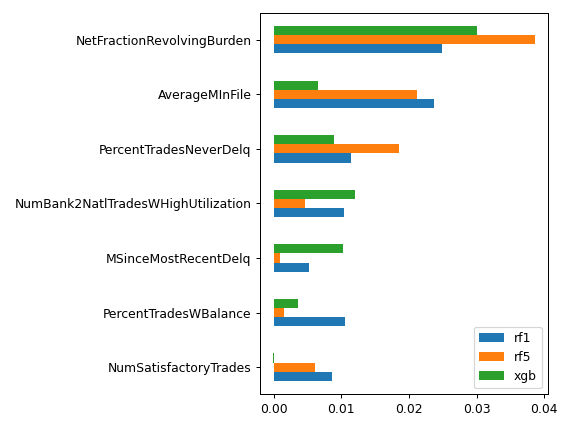

```python
%matplotlib notebook
import matplotlib.pyplot as plt

explnRf1 = eli5.explain_weights(imprtRf1).feature_importances
explnRf5 = eli5.explain_weights(imprtRf5).feature_importances
explnXgb = eli5.explain_weights(xgbImportance).feature_importances

barWidth = 0.25
allData = []
legend = []
varNames = orig.columns[1:]
for (exp, name) in [(explnRf1, "rf1"), (explnRf5, "rf5"), (explnXgb, "xgb")]:
    legend.append(name)
    imps = exp.importances
    l = dict()
    for i in imps:
        index = int(i.feature[1:])
        l[index] = i.weight
    allData.append(list([l[i] if i in l else 0 for i in range(0, len(varNames))]))
# take 7 with greatest sum of weights
sum = [0 for _ in varNames]
for d in allData:
    for i, v in enumerate(d):
        sum[i] = sum[i] + v

sorted = np.argsort(sum).tolist()
sorted.reverse()
sorted = sorted[0:7]
sorted.reverse()
allData = [[d[s] for s in sorted] for d in allData]
varNames = [varNames[s] for s in sorted]

res = pd.DataFrame({'rf1': allData[0], 'rf5': allData[1], 'xgb': allData[2]}, index = varNames)
fig = res.plot.barh()
plt.tight_layout()
```

Zauwazmy że w modelu używającym zmiennej ExternalRiskEstimate jest jedna istotna zmienna, podczas gdy w powyższych trzech modelach nieużywających tej zmennej są zawsze conajmniej trzy zmienne odgrywające znaczącą rolę, takie jak NetFractionRevolvingBurden, AverageMInFile czy PercentTradesNeverDelq. Wynika z tego że usunięcie tej zmiennej prowadzi do lepiej wyjaśnialnego modelu decyzji kredytowych. Wiadomo że zewnętrzny scoring zawsze odgrywa ważną rolę, podczas gdy dla nas istotniejsza jest informacja które konkretnie parametry sytuacji finansowej klienta są brane pod uwagę.

Zmienne pojawiające się jako istotne w powyższych modelach pojawiały się również w poprzednich pracach jako istotne, co potwierdza poprawność wyjaśnienia. Pomimo podobieństw między modelami, takich jak że zmienną z najwyższą wagą we wszystkich modelach jest NetFractionRevolvingBurden, występują też różnice między nimi. W modelu XGBoost drugą z najważniejszych zmiennych jest NumBank2NatlTradesWHighUtilization, podczas gdy w modelach lasu losowego ta zmienna jest odpowiednio na 6-tej.